# Mixed-effects models (I)

Wen Fan

2025-09-25

# Install and load R packages

First, load the necessary libraries and the data. As before, we’ll continue using the PSID data available [here](https://www.dropbox.com/scl/fi/sa44qdsocysjbz8h9sncs/psid.dta?rlkey=bwwfgglu41jbic6zfh6jev0ub&dl=0) to model personal income (`pincome1`). We’ll explore how age (`age`), gender (`female`), race (`race`), education (`yrsch`), and self-rated health (`srh`) affect income over time.

```r
require(tidyverse)
require(haven)
require(sjPlot)
require(lme4)
require(car)
require(plm)
```

Let’s restrict our sample to working-age adults (18-65 years old) and load the data.

```r
psid <- read_dta("/Users/wenfan/Library/CloudStorage/Dropbox/Longitudinal Data/psid.dta")

# Sample selection
psid <- psid |>
  filter(age >= 18 & age <= 65) |>  # Working-age adults
  mutate(log_pincome1 = log(pincome1 + 1)) |>
  mutate(across(c(female, race,), as.factor))
```

# Checking data

```r
# Display data structure
str(psid)
```

```
## tibble [45,538 × 23] (S3: tbl_df/tbl/data.frame)
##  $ id          : num [1:45538] 1001 1001 1001 1002 1002 ...
##   ..- attr(*, "label")= chr "unique ID"
##   ..- attr(*, "format.stata")= chr "%9.0g"
##  $ year        : num [1:45538] 1968 1969 1970 1968 1969 ...
##   ..- attr(*, "format.stata")= chr "%10.0g"
##  $ ykid        : num [1:45538] 0 0 0 0 0 0 0 0 0 0 ...
##   ..- attr(*, "format.stata")= chr "%9.0g"
##  $ region      : dbl+lbl [1:45538] 2, 2, 2, 2, 2, 2, 2, 2, 2, 2, 2, 2, 2, 2, 2, 2, 2, 2...
##    ..@ format.stata: chr "%15.0g"
##    ..@ labels      : Named num [1:5] 1 2 3 4 5
##    .. ..- attr(*, "names")= chr [1:5] "1 Northeast" "2 North Central" "3 South" "4 West" ...
##  $ weight      : num [1:45538] 23 25 25 23 25 25 25 25 25 27 ...
##   ..- attr(*, "format.stata")= chr "%9.0g"
##  $ srh         : num [1:45538] NA NA NA NA NA NA NA NA NA NA ...
##   ..- attr(*, "format.stata")= chr "%9.0g"
##  $ smk1        : num [1:45538] NA NA NA NA NA NA NA NA NA NA ...
##   ..- attr(*, "format.stata")= chr "%9.0g"
##  $ noexe       : num [1:45538] NA NA NA NA NA NA NA NA NA NA ...
##   ..- attr(*, "format.stata")= chr "%9.0g"
##  $ limit       : num [1:45538] NA 1 NA NA NA 0 0 0 0 0 ...
##   ..- attr(*, "format.stata")= chr "%9.0g"
##  $ incomeadj   : num [1:45538] 23365 10818 NA 23365 10818 ...
##   ..- attr(*, "format.stata")= chr "%9.0g"
##  $ yrsch       : num [1:45538] 7 2 NA 7 NA 2 2 7 7 7 ...
##   ..- attr(*, "format.stata")= chr "%9.0g"
##  $ emp         : dbl+lbl [1:45538]  4,  4, NA, NA, NA,  1,  1,  1,  1,  1,  1,  1,  1, ...
##    ..@ format.stata: chr "%27.0g"
##    ..@ labels      : Named num [1:8] 1 2 3 4 5 6 7 8
##    .. ..- attr(*, "names")= chr [1:8] "1 working" "2 temp laid off, sick leave" "3 unemployed" "4 retired" ...
##  $ pincome1    : num [1:45538] 1711 0 NA 3903 4063 ...
##   ..- attr(*, "format.stata")= chr "%9.0g"
##  $ wrkhour     : num [1:45538] 23.1 36 NA 38.5 38.5 ...
##   ..- attr(*, "format.stata")= chr "%9.0g"
##  $ hwsei       : num [1:45538] NA 35.1 NA NA 25.5 ...
##   ..- attr(*, "format.stata")= chr "%8.0g"
##  $ marital     : dbl+lbl [1:45538]  1,  1, NA,  1,  1,  3,  3,  3,  3,  3,  3,  3,  3, ...
##    ..@ format.stata: chr "%11.0g"
##    ..@ labels      : Named num [1:5] 1 2 3 4 5
##    .. ..- attr(*, "names")= chr [1:5] "1 married" "2 single" "3 widowed" "4 divorced" ...
##  $ female      : Factor w/ 2 levels "0","1": 1 1 1 2 2 2 2 2 2 2 ...
##  $ race        : Factor w/ 4 levels "1","2","3","4": 1 1 NA NA NA 1 1 1 1 1 ...
##  $ anykid      : num [1:45538] 0 0 NA 0 0 0 0 0 0 0 ...
##   ..- attr(*, "format.stata")= chr "%9.0g"
##  $ housewrk    : num [1:45538] NA NA NA NA NA NA NA NA NA NA ...
##   ..- attr(*, "format.stata")= chr "%9.0g"
##  $ k6new       : num [1:45538] NA NA NA NA NA NA NA NA NA NA ...
##   ..- attr(*, "format.stata")= chr "%9.0g"
##  $ age         : num [1:45538] 52 53 54 46 47 48 49 50 51 52 ...
##   ..- attr(*, "label")= chr "age"
##   ..- attr(*, "format.stata")= chr "%9.0g"
##  $ log_pincome1: num [1:45538] 7.45 0 NA 8.27 8.31 ...
##   ..- attr(*, "format.stata")= chr "%9.0g"
```

```r
head(psid)
```

```
## # A tibble: 6 × 23
##      id  year  ykid region        weight   srh  smk1 noexe limit incomeadj yrsch
##   <dbl> <dbl> <dbl> <dbl+lbl>      <dbl> <dbl> <dbl> <dbl> <dbl>     <dbl> <dbl>
## 1  1001  1968     0 2 [2 North C…     23    NA    NA    NA    NA    23365.     7
## 2  1001  1969     0 2 [2 North C…     25    NA    NA    NA     1    10818.     2
## 3  1001  1970     0 2 [2 North C…     25    NA    NA    NA    NA       NA     NA
## 4  1002  1968     0 2 [2 North C…     23    NA    NA    NA    NA    23365.     7
## 5  1002  1969     0 2 [2 North C…     25    NA    NA    NA    NA    10818.    NA
## 6  1002  1970     0 2 [2 North C…     25    NA    NA    NA     0     9654.     2
## # ℹ 12 more variables: emp <dbl+lbl>, pincome1 <dbl>, wrkhour <dbl>,
## #   hwsei <dbl>, marital <dbl+lbl>, female <fct>, race <fct>, anykid <dbl>,
## #   housewrk <dbl>, k6new <dbl>, age <dbl>, log_pincome1 <dbl>
```

# Visualization

We can visualize the individual trajectories to get an intuitive sense of the growth patterns in earnings over time.

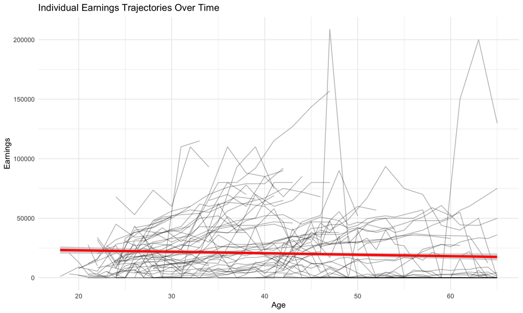

```r
# Plot individual trajectories
set.seed(12)
psid_smp <- psid |> filter(id %in% sample(unique(id), 100)) |> # Sample for clearer visualization
  arrange(id, age)

ggplot(psid_smp, aes(x = age, y = pincome1, group = id)) +
  geom_line(alpha = 0.3) +
  geom_smooth(aes(group = 1), method = "lm", se = TRUE, color = "red", size = 1.5) +
  labs(title = "Individual Earnings Trajectories Over Time",
       x = "Age", y = "Earnings") +
  theme_minimal()
```

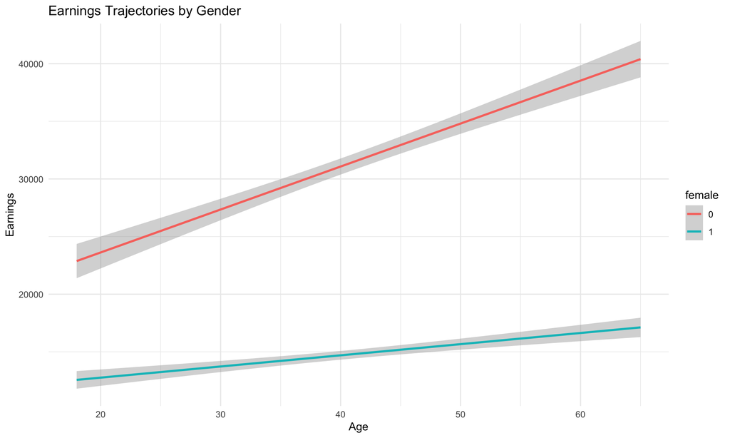

```r
# Plot by groups
ggplot(psid, aes(x = age, y = pincome1, color = female)) +
  geom_smooth(method = "lm", se = TRUE) +
  labs(title = "Earnings Trajectories by Gender",
       x = "Age", y = "Earnings") +
  theme_minimal()
```

# Model building

## Step 1: Unconditional means model

We’ll build a series of mixed-effects models to analyze the longitudinal data. We’ll start with an empty model, also known as an unconditional means model, to assess the variance components. Note that `lmer` specifies random effects using the syntax `(slope | group)`.

```r
# Model 1: Unconditional means model (no predictors, random intercepts only)
model1 <- lmer(log_pincome1 ~ 1 + (1 | id), data = psid, REML = TRUE)
summary(model1)
```

```
## Linear mixed model fit by REML ['lmerMod']
## Formula: log_pincome1 ~ 1 + (1 | id)
##    Data: psid
##
## REML criterion at convergence: 202284.8
##
## Scaled residuals:
##     Min      1Q  Median      3Q     Max
## -4.0827 -0.1762  0.1485  0.4587  3.9156
##
## Random effects:
##  Groups   Name        Variance Std.Dev.
##  id       (Intercept) 8.107    2.847
##  Residual             7.823    2.797
## Number of obs: 39798, groups:  id, 3442
##
## Fixed effects:
##             Estimate Std. Error t value
## (Intercept)  7.82731    0.05333   146.8
```

We can calculate the intra-class correlation (ICC) to obtain the proportion of variance attributable to differences between individuals.

```r
# Calculate ICC
VarCorr(model1) # Display variance components
```

```
##  Groups   Name        Std.Dev.
##  id       (Intercept) 2.8472
##  Residual             2.7969
```

```r
var_components <- as.data.frame(VarCorr(model1))
between_var <- var_components[var_components$grp == "id", "vcov"]
within_var <- var_components[var_components$grp == "Residual", "vcov"]
icc <- between_var / (between_var + within_var)

cat("Intra-class Correlation (ICC):", round(icc, 3), "\n")
```

```
## Intra-class Correlation (ICC): 0.509
```

## Step 2: Unconditional growth model

Next, we will add age as a predictor to model the growth trajectory of earnings over the life course. Note the warning about convergence; this is common in mixed-effects models and we’ll discuss ways to address it later.

```r
# Model 2: Add time with random intercepts and slopes
model2_ri <- lmer(log_pincome1 ~ age + (1 | id), data = psid, REML = TRUE)
summary(model2_ri)
```

```
## Linear mixed model fit by REML ['lmerMod']
## Formula: log_pincome1 ~ age + (1 | id)
##    Data: psid
##
## REML criterion at convergence: 202289.8
##
## Scaled residuals:
##     Min      1Q  Median      3Q     Max
## -4.0516 -0.1848  0.1486  0.4634  3.9356
##
## Random effects:
##  Groups   Name        Variance Std.Dev.
##  id       (Intercept) 8.038    2.835
##  Residual             7.827    2.798
## Number of obs: 39798, groups:  id, 3442
##
## Fixed effects:
##              Estimate Std. Error t value
## (Intercept)  7.979118   0.080821  98.725
## age         -0.003966   0.001592  -2.491
##
## Correlation of Fixed Effects:
##     (Intr)
## age -0.754
```

```r
model2_rs <- lmer(log_pincome1 ~ age  + (age | id), data = psid, REML = TRUE)
summary(model2_rs)
```

```
## Linear mixed model fit by REML ['lmerMod']
## Formula: log_pincome1 ~ age + (age | id)
##    Data: psid
##
## REML criterion at convergence: 196685
##
## Scaled residuals:
##     Min      1Q  Median      3Q     Max
## -5.0290 -0.1609  0.0943  0.3945  3.6601
##
## Random effects:
##  Groups   Name        Variance Std.Dev. Corr
##  id       (Intercept) 34.80868 5.8999
##           age          0.02326 0.1525   -0.89
##  Residual              6.18722 2.4874
## Number of obs: 39798, groups:  id, 3442
##
## Fixed effects:
##              Estimate Std. Error t value
## (Intercept)  8.750991   0.138106   63.36
## age         -0.016864   0.003682   -4.58
##
## Correlation of Fixed Effects:
##     (Intr)
## age -0.923
## optimizer (nloptwrap) convergence code: 0 (OK)
## Model failed to converge with max|grad| = 0.0450706 (tol = 0.002, component 1)
## Model is nearly unidentifiable: very large eigenvalue
##  - Rescale variables?
```

For now, let’s try to address the convergence issue by changing the optimizer to `bobyqa` and increasing the number of iterations for the optimizer (default is 10,000).

```r
model2_rs2 <- lmer(log_pincome1 ~ age  + (age | id), data = psid, REML = TRUE,
                   control = lmerControl(optimizer = "bobyqa", optCtrl = list(maxfun = 2e5)))
summary(model2_rs2)
```

```
## Linear mixed model fit by REML ['lmerMod']
## Formula: log_pincome1 ~ age + (age | id)
##    Data: psid
## Control: lmerControl(optimizer = "bobyqa", optCtrl = list(maxfun = 2e+05))
##
## REML criterion at convergence: 196685
##
## Scaled residuals:
##     Min      1Q  Median      3Q     Max
## -5.0290 -0.1609  0.0943  0.3945  3.6601
##
## Random effects:
##  Groups   Name        Variance Std.Dev. Corr
##  id       (Intercept) 34.80898 5.8999
##           age          0.02326 0.1525   -0.89
##  Residual              6.18725 2.4874
## Number of obs: 39798, groups:  id, 3442
##
## Fixed effects:
##              Estimate Std. Error t value
## (Intercept)  8.751012   0.138106   63.37
## age         -0.016864   0.003682   -4.58
##
## Correlation of Fixed Effects:
##     (Intr)
## age -0.923
## optimizer (bobyqa) convergence code: 0 (OK)
## Model is nearly unidentifiable: very large eigenvalue
##  - Rescale variables?
```

We can compare the two models to see if adding random slopes significantly improves the model fit.

```r
anova(model2_ri, model2_rs2)
```

```
## Data: psid
## Models:
## model2_ri: log_pincome1 ~ age + (1 | id)
## model2_rs2: log_pincome1 ~ age + (age | id)
##            npar    AIC    BIC  logLik -2*log(L)  Chisq Df Pr(>Chisq)
## model2_ri     4 202283 202317 -101137    202275
## model2_rs2    6 196684 196735  -98336    196672 5603.1  2  < 2.2e-16 ***
## ---
## Signif. codes:  0 '***' 0.001 '**' 0.01 '*' 0.05 '.' 0.1 ' ' 1
```

We can also examine the correlation between random intercepts and slopes. In this case, the correlation is negative, suggesting that individuals with higher initial earnings tend to have slower growth rates over time.

```r
# Examine random effects variance-covariance matrix
VarCorr(model2_rs)
```

```
##  Groups   Name        Std.Dev. Corr
##  id       (Intercept) 5.89989
##           age         0.15251  -0.892
##  Residual             2.48741
```

## Step 3: Add time-invariant predictors

Now, we will add baseline characteristics including gender (`female`) and race (`race`).

```r
# Model 3: Add baseline characteristics
model3 <- lmer(log_pincome1 ~ age + female + race + (age | id), data = psid, REML = TRUE,
               control = lmerControl(optimizer = "bobyqa", optCtrl = list(maxfun = 2e5)))
summary(model3)
```

```
## Linear mixed model fit by REML ['lmerMod']
## Formula: log_pincome1 ~ age + female + race + (age | id)
##    Data: psid
## Control: lmerControl(optimizer = "bobyqa", optCtrl = list(maxfun = 2e+05))
##
## REML criterion at convergence: 160298.7
##
## Scaled residuals:
##     Min      1Q  Median      3Q     Max
## -5.3288 -0.1263  0.0880  0.3490  3.9080
##
## Random effects:
##  Groups   Name        Variance Std.Dev. Corr
##  id       (Intercept) 29.24827 5.4082
##           age          0.02136 0.1461   -0.91
##  Residual              5.50553 2.3464
## Number of obs: 33198, groups:  id, 3148
##
## Fixed effects:
##              Estimate Std. Error t value
## (Intercept) 10.422258   0.142885  72.942
## age         -0.029026   0.003678  -7.892
## female1     -1.519546   0.096599 -15.730
## race2       -0.755315   0.178625  -4.228
## race3        0.294719   0.211373   1.394
## race4        0.262431   0.234907   1.117
##
## Correlation of Fixed Effects:
##         (Intr) age    femal1 race2  race3
## age     -0.882
## female1 -0.311  0.001
## race2   -0.086  0.001 -0.019
## race3   -0.065  0.010 -0.013  0.053
## race4   -0.039 -0.002 -0.007  0.037  0.157
## optimizer (bobyqa) convergence code: 0 (OK)
## Model is nearly unidentifiable: very large eigenvalue
##  - Rescale variables?
```

We can also explore interactions between time (age) and these baseline characteristics to see if they influence the growth trajectory.

```r
model3_interactions <- lmer(log_pincome1 ~ age * (female + race) + (age | id), data = psid, REML = TRUE,
                            control = lmerControl(optimizer = "bobyqa", optCtrl = list(maxfun = 2e5)))
summary(model3_interactions)
```

```
## Linear mixed model fit by REML ['lmerMod']
## Formula: log_pincome1 ~ age * (female + race) + (age | id)
##    Data: psid
## Control: lmerControl(optimizer = "bobyqa", optCtrl = list(maxfun = 2e+05))
##
## REML criterion at convergence: 160320.8
##
## Scaled residuals:
##     Min      1Q  Median      3Q     Max
## -5.3280 -0.1270  0.0881  0.3486  3.9067
##
## Random effects:
##  Groups   Name        Variance Std.Dev. Corr
##  id       (Intercept) 29.28655 5.4117
##           age          0.02139 0.1462   -0.91
##  Residual              5.50478 2.3462
## Number of obs: 33198, groups:  id, 3148
##
## Fixed effects:
##              Estimate Std. Error t value
## (Intercept) 10.500991   0.190793  55.039
## age         -0.031390   0.005205  -6.031
## female1     -1.682470   0.270139  -6.228
## race2       -1.324775   0.520278  -2.546
## race3        1.198922   0.694505   1.726
## race4        1.033553   0.804504   1.285
## age:female1  0.004751   0.007370   0.645
## age:race2    0.016426   0.014119   1.163
## age:race3   -0.025901   0.018894  -1.371
## age:race4   -0.020215   0.019380  -1.043
##
## Correlation of Fixed Effects:
##             (Intr) age    femal1 race2  race3  race4  ag:fm1 ag:rc2 ag:rc3
## age         -0.936
## female1     -0.666  0.625
## race2       -0.179  0.166 -0.027
## race3       -0.113  0.103 -0.008  0.059
## race4       -0.092  0.080 -0.004  0.040  0.086
## age:female1  0.624 -0.669 -0.934  0.026  0.006  0.002
## age:race2    0.168 -0.177  0.025 -0.939 -0.061 -0.035 -0.027
## age:race3    0.106 -0.108  0.005 -0.059 -0.952 -0.086 -0.004  0.067
## age:race4    0.091 -0.088  0.002 -0.039 -0.106 -0.956 -0.001  0.037  0.122
## optimizer (bobyqa) convergence code: 0 (OK)
## Model is nearly unidentifiable: very large eigenvalue
##  - Rescale variables?
```

## Step 4: Add time-varying predictors

Lastly, let’s include time-varying predictors such as education (`yrsch`) and self-rated health (`srh`). Below the time-varying predictor `yrsch` is decomposed into within-person and between-person components.

```r
psid$yrsch_gmc <- psid$yrsch - mean(psid$yrsch, na.rm = TRUE)  # Grand-mean centered
psid$yrsch_pmc <- psid$yrsch - ave(psid$yrsch, psid$id, FUN = function(x) mean(x, na.rm = TRUE)) # Person-mean centered
psid$yrsch_between <- ave(psid$yrsch, psid$id, FUN = function(x) mean(x, na.rm = TRUE))  # Between-person component

# Within-between decomposition model
model4 <- lmer(log_pincome1 ~ age + female + race + srh +
                yrsch_pmc + yrsch_between +  # Within and between effects of education
                (age | id), data = psid, REML = TRUE,
               control = lmerControl(optimizer = "bobyqa", optCtrl = list(maxfun = 2e5)))
summary(model4)
```

```
## Linear mixed model fit by REML ['lmerMod']
## Formula:
## log_pincome1 ~ age + female + race + srh + yrsch_pmc + yrsch_between +
##     (age | id)
##    Data: psid
## Control: lmerControl(optimizer = "bobyqa", optCtrl = list(maxfun = 2e+05))
##
## REML criterion at convergence: 123236.6
##
## Scaled residuals:
##     Min      1Q  Median      3Q     Max
## -4.6918 -0.1251  0.0880  0.3518  3.7786
##
## Random effects:
##  Groups   Name        Variance Std.Dev. Corr
##  id       (Intercept) 34.90125 5.9077
##           age          0.02351 0.1533   -0.93
##  Residual              6.04866 2.4594
## Number of obs: 24950, groups:  id, 2696
##
## Fixed effects:
##                Estimate Std. Error t value
## (Intercept)    5.757931   0.352010  16.357
## age           -0.032018   0.004266  -7.505
## female1       -1.742670   0.105717 -16.484
## race2         -0.103559   0.211805  -0.489
## race3          0.662069   0.232840   2.843
## race4          0.195505   0.256014   0.764
## srh            0.239934   0.025285   9.489
## yrsch_pmc      0.196069   0.030070   6.521
## yrsch_between  0.308335   0.022919  13.453
##
## Correlation of Fixed Effects:
##             (Intr) age    femal1 race2  race3  race4  srh    yrsch_p
## age         -0.467
## female1     -0.123  0.018
## race2       -0.103 -0.010 -0.016
## race3       -0.094  0.016 -0.016  0.058
## race4        0.003 -0.006 -0.004  0.036  0.154
## srh         -0.222  0.140  0.044  0.017  0.007  0.004
## yrsch_pmc   -0.089 -0.088  0.023  0.003 -0.003 -0.019 -0.012
## yrsch_betwn -0.809 -0.002 -0.056  0.079  0.072 -0.023 -0.142  0.103
## optimizer (bobyqa) convergence code: 0 (OK)
## Model is nearly unidentifiable: very large eigenvalue
##  - Rescale variables?
```

Similarly, we can center age (the time variable) for interpretability. For example, centering age at baseline, grand-mean centering, or centering at a meaningful value (e.g., 40 years old). Note that centering affects the interpretation of the intercept.

```r
psid$age_baseline <- psid$age  # Age centered at baseline (0)
psid$age_gmc <- psid$age - mean(psid$age, na.rm = TRUE)  # Grand-mean centered
psid$age_40 <- psid$age - 40  # Center age at 40

# Compare models with different time centering
model_baseline <- lmer(log_pincome1 ~ age_baseline + female + race + srh + yrsch + (age_baseline | id), data = psid, REML = TRUE, control = lmerControl(optimizer = "bobyqa", optCtrl = list(maxfun = 2e5)))

model_gmc <- lmer(log_pincome1 ~ age_gmc + female + race + srh + yrsch + (age_gmc | id), data = psid, REML = TRUE, control = lmerControl(optimizer = "bobyqa", optCtrl = list(maxfun = 2e5)))

model_40 <- lmer(log_pincome1 ~ age_40 + female + race + srh + yrsch + (age_40 | id), data = psid, REML = TRUE, control = lmerControl(optimizer = "bobyqa", optCtrl = list(maxfun = 2e5)))

tab_model(model_baseline, model_gmc, model_40,
          show.re.var = TRUE,
          show.icc = TRUE,
          show.obs = TRUE,
          title = "Models with Different Time Centering")
```

Models with Different Time Centering

|  | log_pincome1 |  |  | log_pincome1 |  |  | log_pincome1 |  |  |
| --- | --- | --- | --- | --- | --- | --- | --- | --- | --- |
| Predictors | Estimates | CI | p | Estimates | CI | p | Estimates | CI | p |
| (Intercept) | 6.24 | 5.63 – 6.86 | **<0.001** | 4.98 | 4.44 – 5.52 | **<0.001** | 4.93 | 4.38 – 5.47 | **<0.001** |
| age | -0.03 | -0.04 – -0.02 | **<0.001** |  |  |  |  |  |  |
| female: female1 | -1.73 | -1.93 – -1.52 | **<0.001** | -1.73 | -1.93 – -1.52 | **<0.001** | -1.73 | -1.93 – -1.52 | **<0.001** |
| race: race2 | -0.14 | -0.55 – 0.28 | 0.521 | -0.14 | -0.55 – 0.28 | 0.521 | -0.14 | -0.55 – 0.28 | 0.521 |
| race: race3 | 0.63 | 0.17 – 1.08 | **0.007** | 0.63 | 0.17 – 1.08 | **0.007** | 0.63 | 0.17 – 1.08 | **0.007** |
| race: race4 | 0.19 | -0.31 – 0.69 | 0.450 | 0.19 | -0.31 – 0.69 | 0.450 | 0.19 | -0.31 – 0.69 | 0.450 |
| srh | 0.25 | 0.20 – 0.30 | **<0.001** | 0.25 | 0.20 – 0.30 | **<0.001** | 0.25 | 0.20 – 0.30 | **<0.001** |
| yrsch | 0.27 | 0.23 – 0.31 | **<0.001** | 0.27 | 0.23 – 0.31 | **<0.001** | 0.27 | 0.23 – 0.31 | **<0.001** |
| age |  |  |  | -0.03 | -0.04 – -0.02 | **<0.001** |  |  |  |
| age |  |  |  |  |  |  | -0.03 | -0.04 – -0.02 | **<0.001** |
| Random Effects |  |  |  |  |  |  |  |  |  |
| σ<sup>2</sup> | 6.05 |  |  | 6.05 |  |  | 6.05 |  |  |
| τ<sub>00</sub> | 34.73 <sub>id</sub> |  |  | 5.17 <sub>id</sub> |  |  | 5.43 <sub>id</sub> |  |  |
| τ<sub>11</sub> | 0.02 <sub>id.age_baseline</sub> |  |  | 0.02 <sub>id.age_gmc</sub> |  |  | 0.02 <sub>id.age_40</sub> |  |  |
| ρ<sub>01</sub> | -0.93 <sub>id</sub> |  |  | 0.19 <sub>id</sub> |  |  | 0.29 <sub>id</sub> |  |  |
| ICC | 0.59 |  |  | 0.59 |  |  | 0.59 |  |  |
| N | 2696 <sub>id</sub> |  |  | 2696 <sub>id</sub> |  |  | 2696 <sub>id</sub> |  |  |
| Observations | 24950 |  |  | 24950 |  |  | 24950 |  |  |
| Marginal R<sup>2</sup> / Conditional R<sup>2</sup> | 0.096 / 0.633 |  |  | 0.096 / 0.633 |  |  | 0.096 / 0.633 |  |  |

# Nonlinear growth patterns

We can explore nonlinear growth patterns by adding polynomial terms or piecewise linear terms. The piecewise linear model can be useful if we expect different growth rates at different life stages. The coefficients can be interpreted as the change in earnings per year before and after the knot point (e.g., age 40).

```r
# Quadratic growth model
model_quad <- lmer(log_pincome1 ~ age + I(age^2) + (age | id), data = psid, REML = TRUE,
                   control = lmerControl(optimizer = "bobyqa", optCtrl = list(maxfun = 2e5)))
summary(model_quad)
```

```
## Linear mixed model fit by REML ['lmerMod']
## Formula: log_pincome1 ~ age + I(age^2) + (age | id)
##    Data: psid
## Control: lmerControl(optimizer = "bobyqa", optCtrl = list(maxfun = 2e+05))
##
## REML criterion at convergence: 195413.5
##
## Scaled residuals:
##     Min      1Q  Median      3Q     Max
## -4.6831 -0.1467  0.0869  0.3848  3.8646
##
## Random effects:
##  Groups   Name        Variance Std.Dev. Corr
##  id       (Intercept) 35.46429 5.9552
##           age          0.02235 0.1495   -0.89
##  Residual              5.96928 2.4432
## Number of obs: 39798, groups:  id, 3442
##
## Fixed effects:
##              Estimate Std. Error t value
## (Intercept)  1.806848   0.236524   7.639
## age          0.348461   0.010715  32.520
## I(age^2)    -0.004533   0.000125 -36.275
##
## Correlation of Fixed Effects:
##          (Intr) age
## age      -0.946
## I(age^2)  0.812 -0.941
## fit warnings:
## Some predictor variables are on very different scales: consider rescaling
## optimizer (bobyqa) convergence code: 0 (OK)
## Model failed to converge with max|grad| = 0.00532891 (tol = 0.002, component 1)
## Model is nearly unidentifiable: very large eigenvalue
##  - Rescale variables?
```

```r
# Piecewise linear growth
psid$age_40 <- pmax(0, psid$age - 40) # Create a piecewise linear spline for age after 40

model_piecewise <- lmer(log_pincome1 ~ age + age_40 + (age | id), data = psid, REML = TRUE,
                        control = lmerControl(optimizer = "bobyqa", optCtrl = list(maxfun = 2e5)))
summary(model_piecewise)
```

```
## Linear mixed model fit by REML ['lmerMod']
## Formula: log_pincome1 ~ age + age_40 + (age | id)
##    Data: psid
## Control: lmerControl(optimizer = "bobyqa", optCtrl = list(maxfun = 2e+05))
##
## REML criterion at convergence: 195832.6
##
## Scaled residuals:
##     Min      1Q  Median      3Q     Max
## -4.7849 -0.1519  0.0921  0.3823  3.8062
##
## Random effects:
##  Groups   Name        Variance Std.Dev. Corr
##  id       (Intercept) 34.93113 5.9103
##           age          0.02226 0.1492   -0.89
##  Residual              6.04842 2.4594
## Number of obs: 39798, groups:  id, 3442
##
## Fixed effects:
##              Estimate Std. Error t value
## (Intercept)  6.230570   0.162148   38.42
## age          0.062747   0.004515   13.90
## age_40      -0.167849   0.005677  -29.57
##
## Correlation of Fixed Effects:
##        (Intr) age
## age    -0.943
## age_40  0.529 -0.600
## optimizer (bobyqa) convergence code: 0 (OK)
## Model is nearly unidentifiable: very large eigenvalue
##  - Rescale variables?
```

# Hausman test

To compare mixed-effects models with fixed-effects models, we can use the Hausman test. The `plm` package allows us to fit both fixed and random effects models and perform the Hausman test to determine if the random effects model is appropriate.

```r
# Create panel data
panel_data <- pdata.frame(psid, index = c("id", "age"))

# Fixed effects model
fe_model <- plm(log_pincome1 ~ age + yrsch + srh, data = panel_data, model = "within")

# Random effects model
re_model <- plm(log_pincome1 ~ age + yrsch + srh, data = panel_data, model = "random")

# Hausman test
phtest(fe_model, re_model)
```

```
##
##  Hausman Test
##
## data:  log_pincome1 ~ age + yrsch + srh
## chisq = 196.38, df = 49, p-value < 2.2e-16
## alternative hypothesis: one model is inconsistent
```